# Quiz 04: In-Class

Complete this quiz in a .Rmd file. To turn in the quiz, push both a .Rmd file and a knitted .html file to your GitHub site.

## Statement of Integrity:

“All work presented is my own. I have not communicated with or worked with anyone else on this quiz.” Jessica Tom

Collaboration Reminder: You may not communicate with or work with anyone else on this quiz, but you may use any of our course materials or materials on the Internet.

## Question 1 (20 points).

Examine the alcohol.csv data set that you may have used as an introductory data set in STAT/DATA 234:

```r
library(tidyverse)
library(here)
alcohol_df <- read_csv(here("data/alcohol.csv"))
```

The data set has the following variables on countries throughout the world:

- country, the name of the country
- beer_servings, the number of beer servings per person per year
- spirit_servings, the number of spirit servings per person per year
- wine_servings, the number of wine servings per person per year
- total_litres_of_pure_alcohol, the number of litres of pure alcohol consumed per person per year

Construct a map of the beer_servings variable. You should choose an appropriate projection and change the default colour scheme of your map.

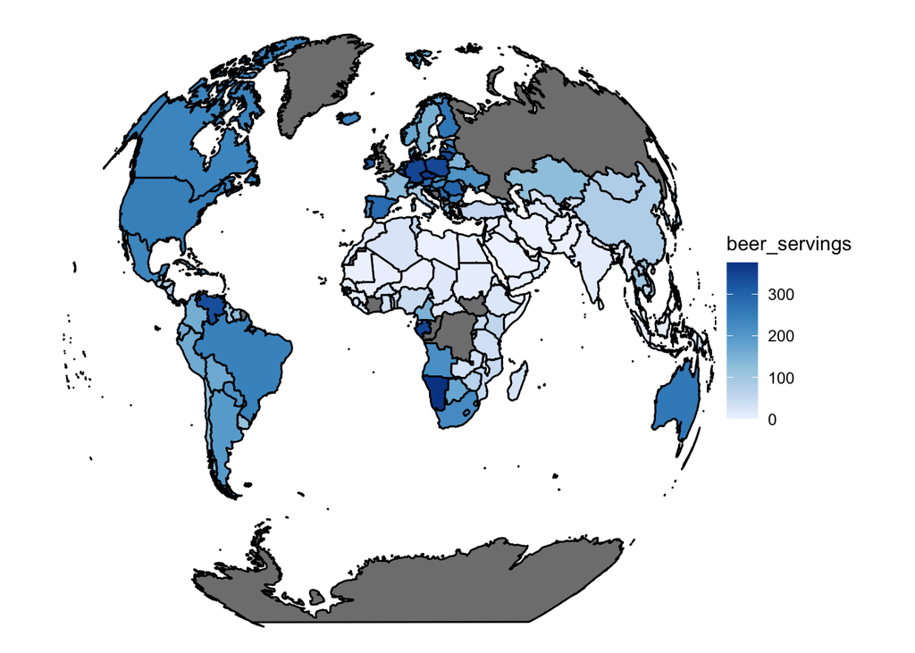

```r
world_df <- ggplot2::map_data("world")
world_beer <- left_join(world_df, alcohol_df, by = c("region" = "country"))
ggplot(data = world_beer,
            mapping = aes(x = long, y = lat,
                          group = group)) +
  geom_polygon(colour = "black", aes(fill = beer_servings)) +
  coord_map(projection = "gilbert", xlim=c(-180,180)) +
  theme_void() +
  scale_fill_distiller(direction = 1)
```

## Question 2 (5 points).

Give an example of a question of interest about the alcohol data where you would want to construct a visualization other than a map to answer the question. What type of visualization would you construct instead?